# Mundo do trabalho e renda da população negra

Pablo Castro

2026-06-19

# 1 Introdução

O mercado de trabalho é um dos espaços em que as desigualdades raciais brasileiras se manifestam de forma mais direta. Salário, formalidade, posição hierárquica e estabilidade ocupacional são dimensões em que o pertencimento racial se traduz em diferenças mensuráveis de oportunidade e proteção social. Este texto analisa essas diferenças com base nos resultados do Censo Demográfico 2022, em coerência com o escopo definido para o Produto 4 do Plano de Trabalho.

A análise se organiza em três blocos. O primeiro descreve a participação da população negra na força de trabalho e a distribuição territorial da ocupação. O segundo examina a segregação ocupacional, considerando tanto os grandes grupos de atividade quanto a posição na ocupação (com ou sem carteira, doméstico, conta própria, empregador, setor público). O terceiro discute os diferenciais de rendimento por nível de instrução, grupo ocupacional e unidade da federação. A categoria “negra” agrega pretas e pardas, conforme classificação do IBGE; “não negra” reúne brancas, amarelas e indígenas. Sempre que cabível, foram aplicadas ponderações populacionais para que as médias agregadas reflitam o peso de cada subgrupo nas populações ocupadas.

# 2 Participação no mercado de trabalho

A primeira leitura das informações do Censo 2022 mostra que a participação na força de trabalho é semelhante entre os dois grupos raciais, mas a ocupação efetiva e o desemprego seguem padrões distintos. A taxa de atividade da população negra de 14 anos ou mais é de 56,0%, contra 57,7% entre não negros — diferença de 1,8 ponto percentual. A taxa de ocupação, no entanto, é de 52,3% entre negros e 55,1% entre não negros, e a taxa de desemprego é 6,6% entre negros, contra 4,5% entre não negros, o que representa um desemprego 46% maior para a população negra.

## 2.1 Condição na força de trabalho por nível de instrução

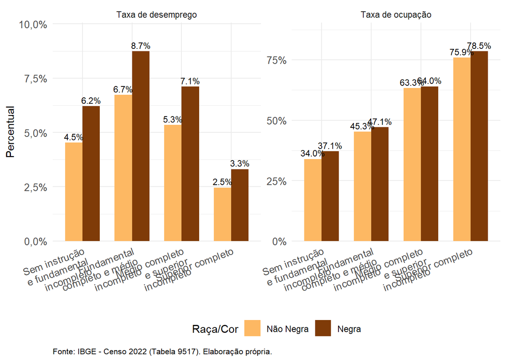

Figura 2.1: Taxas de ocupação e desemprego por raça/cor e nível de instrução, Brasil, 2022

## 2.2 Taxa de desocupação da população negra por município

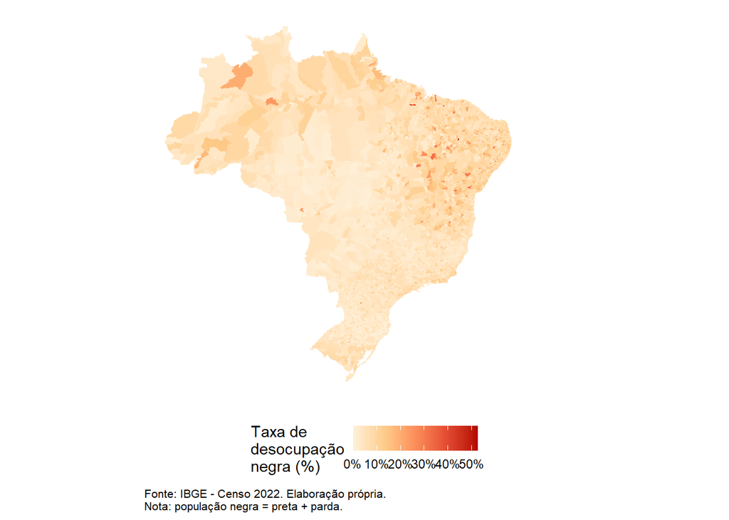

Figura 2.2: Taxa de desocupação da população negra por município, Brasil, 2022

A Figura 2.2 revela padrões intraestaduais que não são visíveis na escala da UF. As maiores taxas de desocupação da população negra concentram-se em municípios do interior do Nordeste — especialmente no Sertão de Alagoas, Bahia e Piauí —, além de algumas áreas da Amazônia. No polo oposto, municípios do interior do Sul e Centro-Oeste, bem como cidades com forte presença do agronegócio formal, exibem taxas mais baixas. Essa leitura municipal reforça que as oportunidades de inserção produtiva para a população negra estão condicionadas pela dinâmica local do mercado de trabalho, com forte correlação entre desocupação e ausência de estruturas produtivas diversificadas. O cruzamento desses dados com os indicadores de governança local do MUNIC 2024 (ver Texto 1 desta consultoria) permite identificar com precisão os municípios em que vulnerabilidade racial e ausência institucional se combinam.

# 3 Segregação ocupacional

A segregação ocupacional opera em dois sentidos. No sentido horizontal, a população negra se distribui de forma diferente da não negra pelos grandes grupos de ocupação. No sentido vertical, ocupa posições mais frágeis dentro de cada grupo. As duas dimensões aparecem com clareza nos resultados do Censo 2022.

## 3.1 Distribuição por grandes grupos ocupacionais

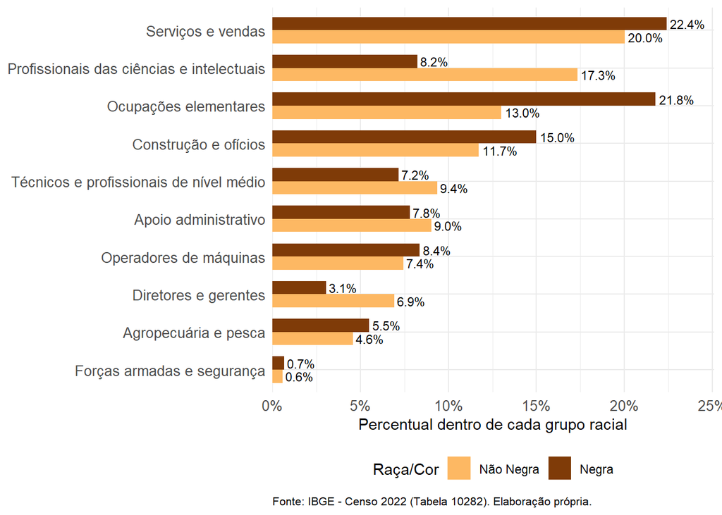

Figura 3.1: Distribuição percentual das pessoas ocupadas por grandes grupos ocupacionais e raça/cor, Brasil, 2022

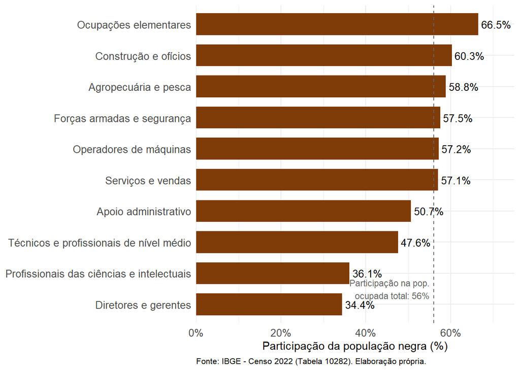

Figura 3.2: Participação da população negra em cada grande grupo ocupacional, Brasil, 2022

A Figura 3.2 inverte o ponto de vista e mostra a participação da população negra dentro de cada grande grupo ocupacional. A linha de referência indica a participação da população negra no total de pessoas ocupadas no Brasil — 56%. Em diretores e gerentes, essa participação cai para 34,4%; em profissionais das ciências e intelectuais, para 36,1%. Em sentido contrário, as pessoas negras representam 66,5% das ocupações elementares e 60,3% das ocupações de construção e ofícios. Trata-se da expressão direta da segregação vertical, em que a sub-representação no topo e a sobre-representação na base ocorrem simultaneamente.

## 3.2 Posição na ocupação

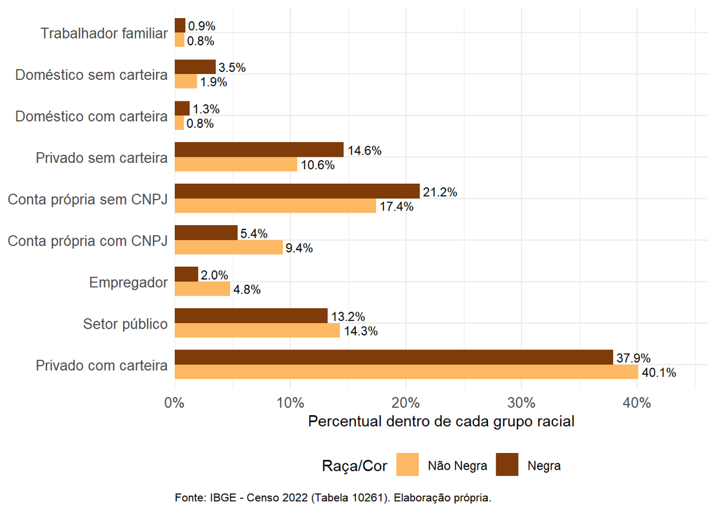

Figura 3.3: Distribuição das pessoas ocupadas por posição no trabalho principal e raça/cor, Brasil, 2022

# 4 Diferenciais de rendimento

Os diferenciais salariais sintetizam o efeito acumulado das desigualdades nos eixos anteriores: nível de instrução, tipo de ocupação e território. O Censo 2022 permite observá-los nas três dimensões.

## 4.1 Rendimento médio por nível de instrução

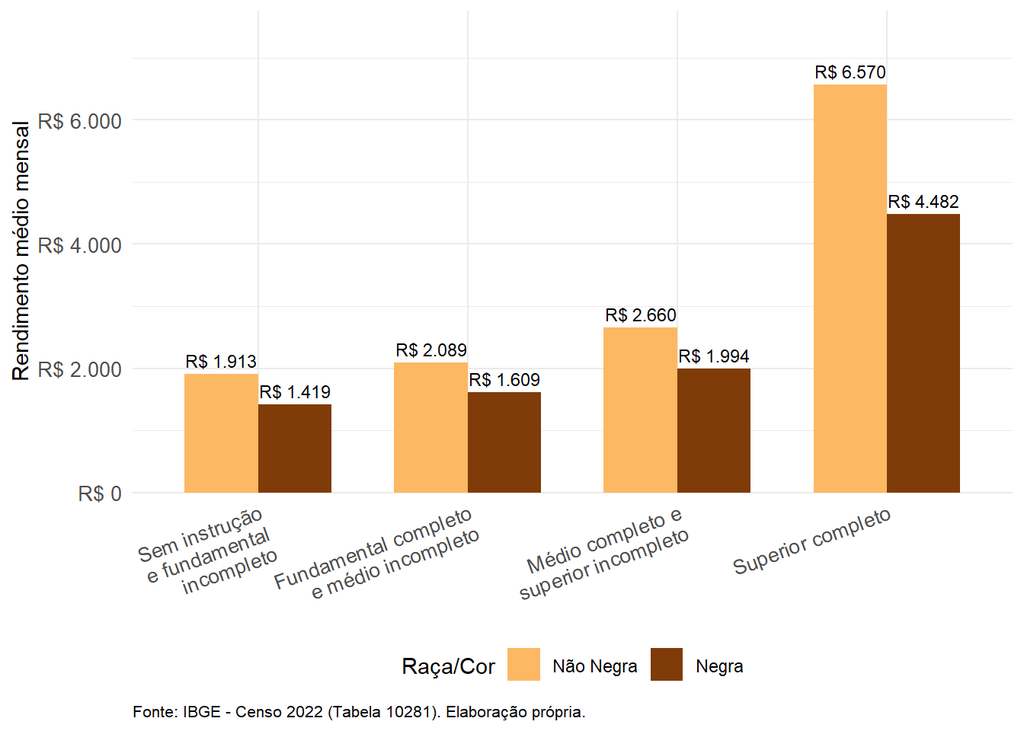

Figura 4.1: Rendimento nominal médio mensal por raça/cor e nível de instrução, Brasil, 2022

A Figura 4.1 revela que a desigualdade salarial não se desfaz com a escolaridade. Entre quem tem ensino superior completo, o rendimento médio mensal da população negra é de R$ 4.482, contra R$ 6.570 entre a não negra — diferença de R$ 2.088 ou cerca de R$ 25 mil por ano. Nos demais níveis, o rendimento da população negra equivale a 74% (sem instrução), 77% (fundamental) e 75% (médio) do rendimento da população não negra. No ensino superior, essa razão cai para 68%, indicando que a maior distância salarial em valores absolutos coincide com a maior distância relativa. O fenômeno é compatível com diferentes hipóteses já investigadas pela literatura: concentração de pessoas negras com ensino superior em carreiras de menor remuneração, segregação dentro das mesmas carreiras e barreiras de acesso a posições de chefia.

## 4.2 Rendimento médio por grupo ocupacional

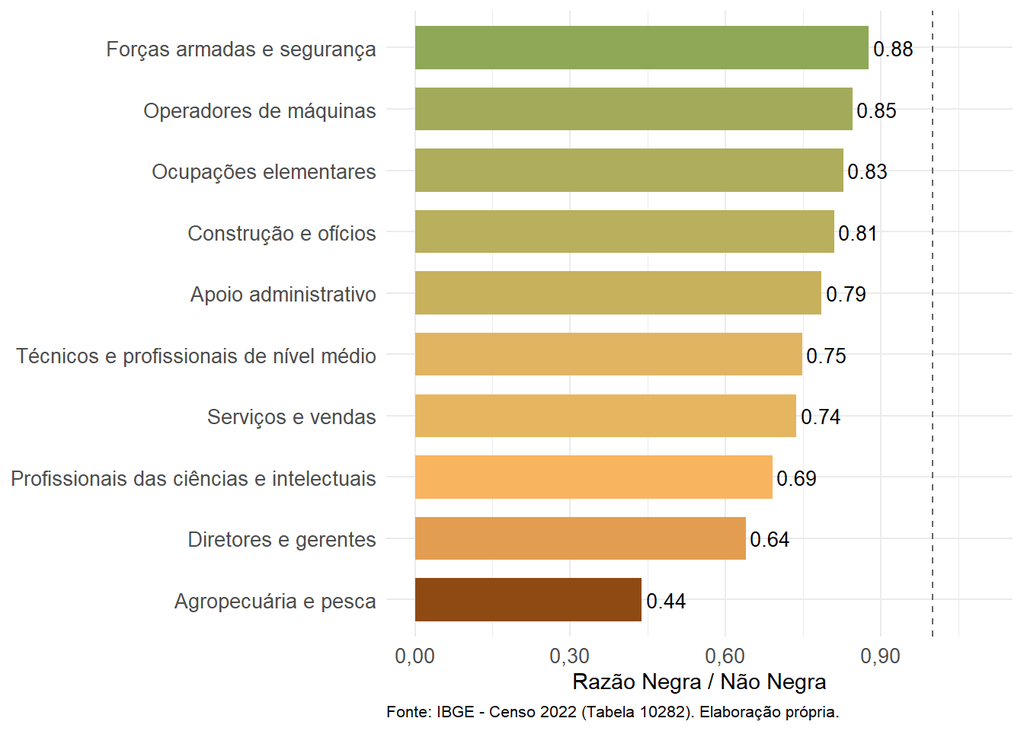

Figura 4.2: Razão entre rendimento médio da população negra e não negra por grande grupo ocupacional, Brasil, 2022

A Figura 4.2 traz a razão entre o rendimento médio da população negra e não negra dentro de cada grande grupo ocupacional. Mesmo quando o tipo de trabalho é o mesmo, o salário médio difere. A razão é menor entre trabalhadores qualificados da agropecuária (0,44), diretores e gerentes (0,64), e profissionais das ciências e intelectuais (0,69). Esses três grupos compreendem, respectivamente, atividades rurais frequentemente marcadas por relações de trabalho informais e atividades urbanas que costumam reunir as posições mais bem pagas da estrutura ocupacional. A razão fica mais próxima da paridade entre operadores de máquinas (0,85), forças armadas e segurança (0,88) e ocupações elementares (0,83) — grupos em que a remuneração base é mais padronizada por convenção, regulamentação ou natureza do trabalho. O resultado mostra que o hiato racial varia conforme o grau de discricionariedade salarial: quanto mais o salário depende de negociação individual, mérito subjetivamente avaliado ou posição hierárquica, maior tende a ser a desvantagem da população negra.

## 4.3 Rendimento médio da população negra: razão por UF e distribuição municipal

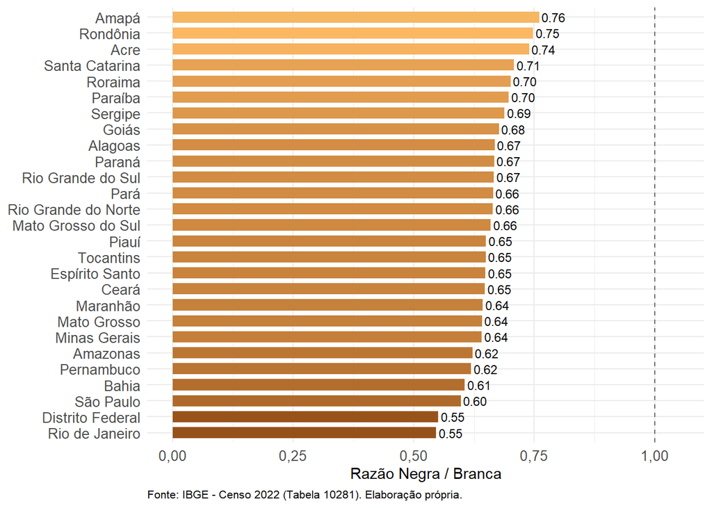

Figura 4.3: Razão entre rendimento médio da população negra e da população branca por UF, Brasil, 2022

[figure not shown]

Figura 4.4: Rendimento médio da população negra por município, Brasil, 2022

A Figura 4.4 desagrega o rendimento médio da população negra ao nível municipal, revelando padrões intraestaduais que a escala da UF não captura. Os municípios com rendimentos mais elevados concentram-se nas regiões metropolitanas do Sul e Sudeste — Grande São Paulo, Porto Alegre, Curitiba e Campinas — e em municípios do agronegócio do Centro-Oeste com alto valor adicionado. No Nordeste, os tons mais escuros se limitam às capitais e alguns municípios polo regionais, enquanto o interior apresenta rendimentos médios muito baixos para a população negra. Em termos de política pública, esse mapa sugere que programas de geração de renda e qualificação profissional direcionados à população negra precisam ser desenhados em escala municipal, uma vez que as necessidades variam substancialmente mesmo dentro de uma mesma UF.

# 5 Considerações finais

O Censo 2022 oferece uma fotografia consistente: a população negra participa em ritmo semelhante do mercado de trabalho, mas sofre um desemprego sistematicamente maior, ocupa posições menos protegidas dentro de cada grupo ocupacional e recebe rendimentos médios inferiores em todos os níveis de instrução e em todos os grandes grupos de ocupação. O hiato salarial atinge 32 pontos percentuais entre quem tem ensino superior e 56 pontos percentuais entre trabalhadores qualificados da agropecuária. A desigualdade é mais aguda exatamente onde estão as ocupações mais bem pagas e os mercados de trabalho mais diversificados — Rio de Janeiro, Distrito Federal, São Paulo —, o que reforça o argumento de que o problema não está no acesso ao trabalho em si, mas na posição que cada grupo ocupa dentro da estrutura produtiva.

Esses resultados sustentam quatro implicações para o desenho de políticas. Primeiro, as ações afirmativas de acesso ao ensino superior, que já alteraram a presença racial no topo da escolaridade, precisam ser acompanhadas de mecanismos que ataquem o hiato salarial dentro das mesmas ocupações — desde transparência salarial em empresas privadas até critérios objetivos para promoção e progressão funcional. Segundo, a regulação e a fiscalização do trabalho doméstico e do trabalho por conta própria sem CNPJ, posições em que a sobre-representação da população negra é mais evidente, são instrumentos diretos de redução de informalidade racializada. Terceiro, o setor público continua sendo um dos poucos espaços do mercado de trabalho em que a participação racial se aproxima da composição populacional; a manutenção e o aprofundamento das cotas raciais no serviço público — nos termos da Lei nº 12.990/2014 — se justificam tanto pela função compensatória quanto pelo efeito demonstrativo sobre o restante do mercado. Quarto, a desagregação municipal dos dados de desocupação e rendimento aqui apresentada deve subsidiar os municípios signatários do Sistema Nacional de Promoção da Igualdade Racial (SINAPIR) na elaboração de planos locais de emprego e renda com recorte racial, priorizando os territórios em que alta desocupação e baixo rendimento da população negra se sobrepõem.

# Referências

BRASIL. Lei nº 12.288, de 20 de julho de 2010. Institui o Estatuto da Igualdade Racial. Brasília: Diário Oficial da União, 2010.

CACCIAMALI, Maria Cristina; HIRATA, Guilherme Issamu. A influência do gênero, da raça/cor e da escolaridade sobre os rendimentos do trabalho. São Paulo: USP, 2005.

CAMPANTE, Felipe; CRESPO, Anna; LEITE, Phillippe. Desigualdade salarial entre raças no mercado de trabalho urbano brasileiro: aspectos regionais. Revista Brasileira de Economia, v. 58, n. 2, p. 185–210, 2004.

DIEESE. A inserção dos negros e das negras nos mercados de trabalho metropolitanos. São Paulo: DIEESE, 2023.

IBGE. Censo Demográfico 2022 – Trabalho. Tabelas 9517, 10261, 10281 e 10282. Rio de Janeiro: IBGE, 2024.

IPEA. Retrato das desigualdades de gênero e raça. Brasília: IPEA/SPM/ONU Mulheres, 2022.

OSORIO, Rafael Guerreiro. Desigualdade racial e mobilidade social no Brasil: um balanço das teorias. In: THEODORO, Mário (org.). As políticas públicas e a desigualdade racial no Brasil 120 anos após a abolição. Brasília: IPEA, 2008.

SOARES, Sergei. O perfil da discriminação no mercado de trabalho: homens negros, mulheres brancas e mulheres negras. Brasília: IPEA, 2000. (Texto para Discussão n. 769).